# Bacteriophytochrome

## Figure 4: Best-cluster predicted contact maps over the two true folds.

Predicted contact maps (MSA-Transformer) for the clusters best matching each fold, over the true contacts of fold 1 (upper triangle) and fold 2 (lower). Divergent contacts between clusters are the contact-level signature of fold-switching.

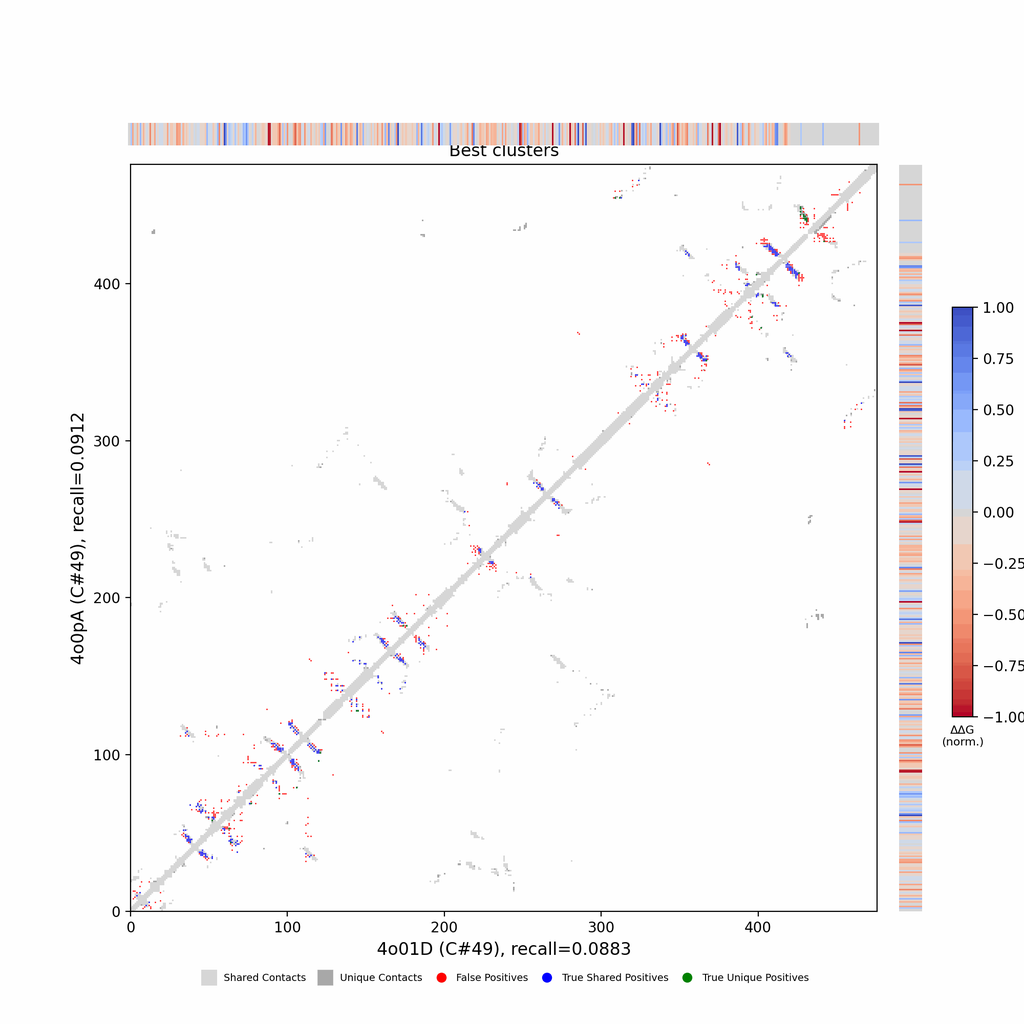

## Figure 5: Per-residue ΔΔG fold-preference contribution

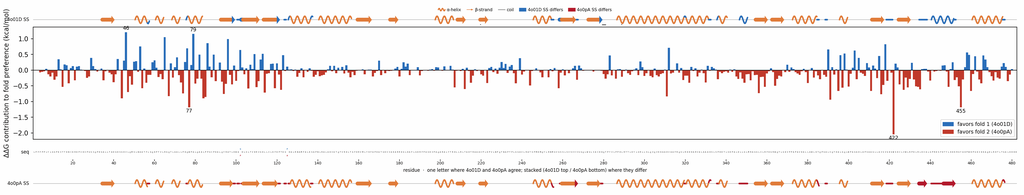

**More figures**

## Figure 6: Deep-MSA contact map panel / Best clusters contact map panel

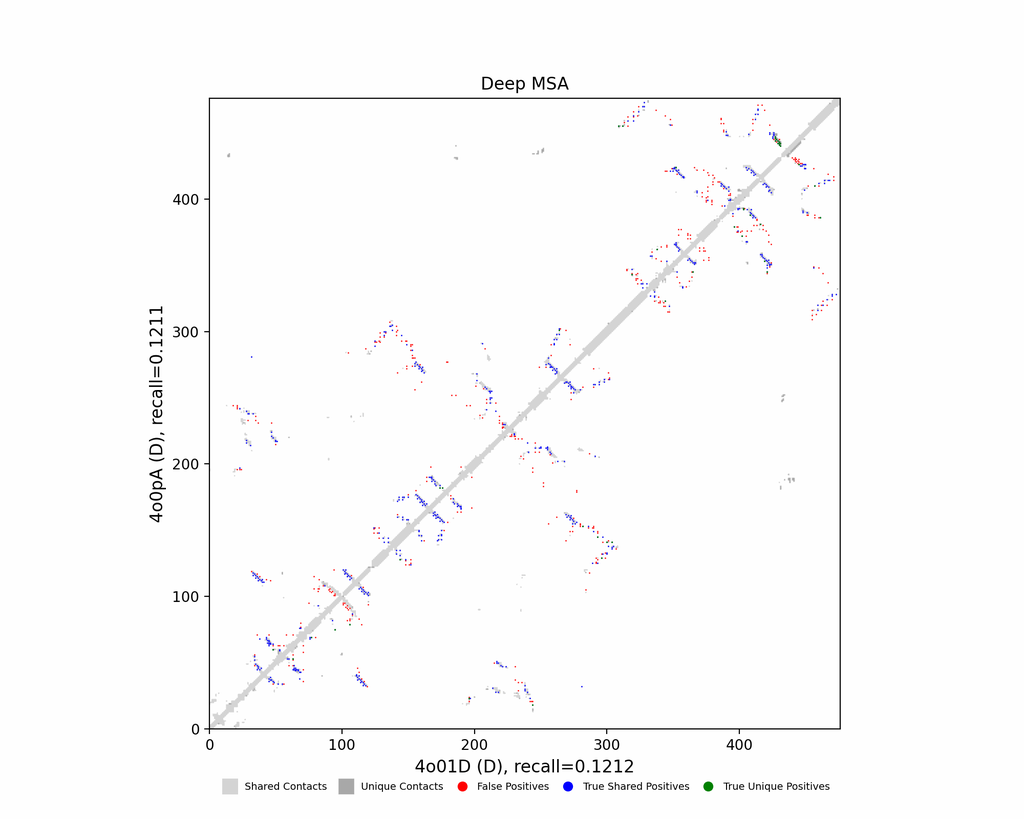

Deep-MSA contact map panel

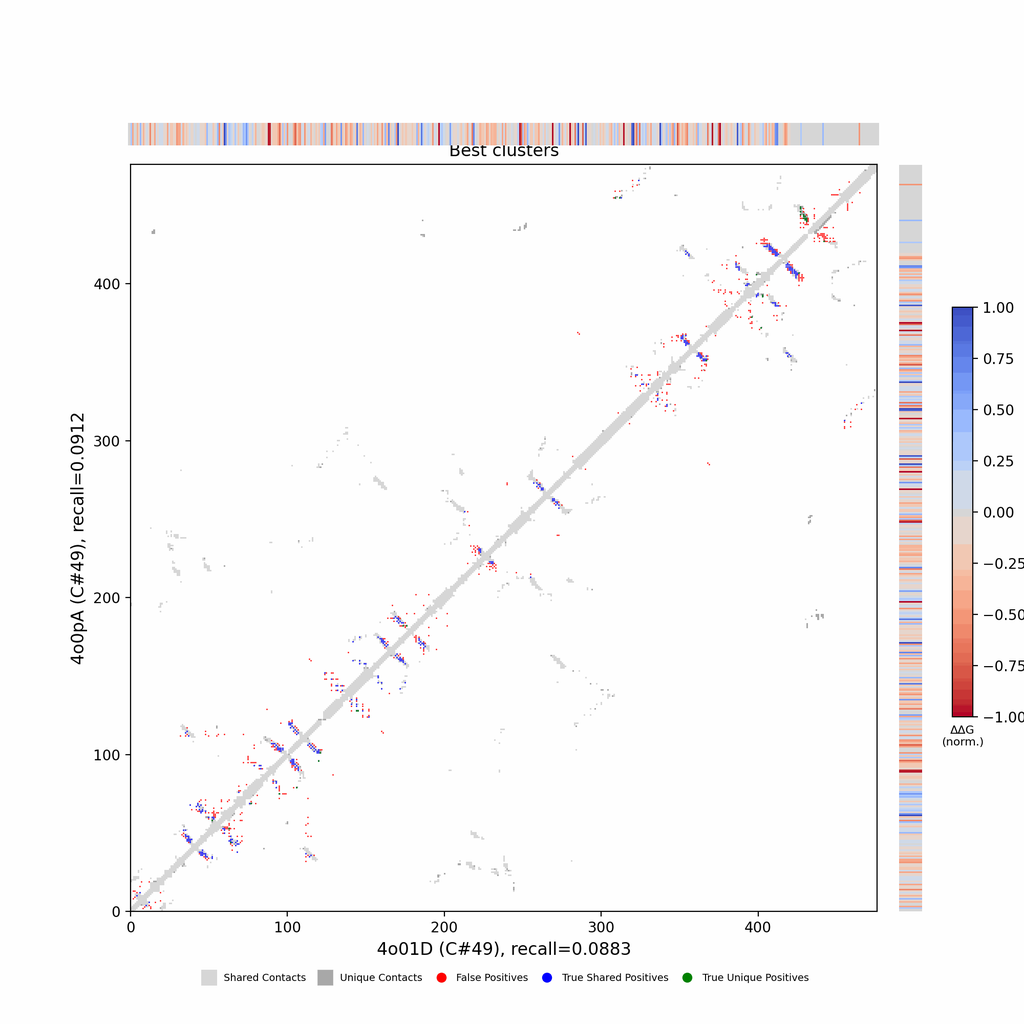

Best clusters contact map panel

## Figure 7: All clusters contact-map mosaic (small multiples).

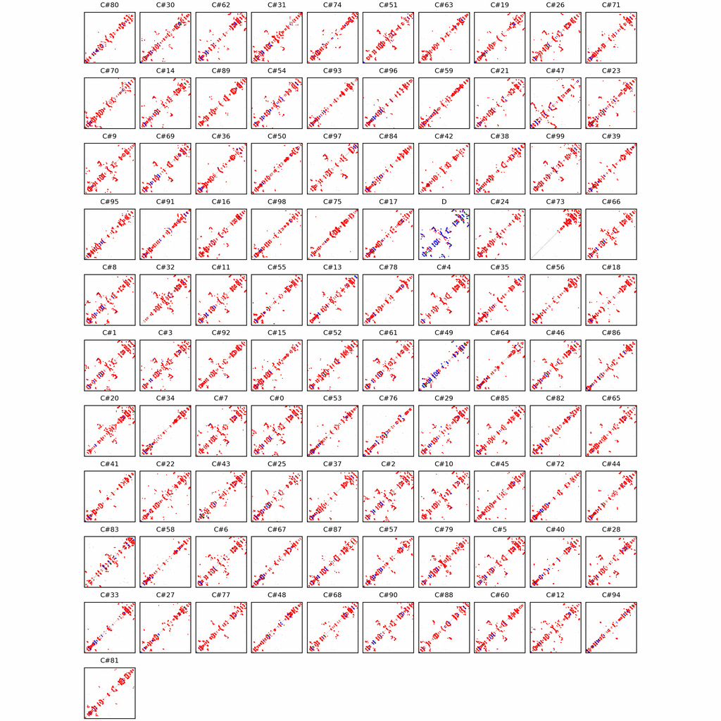

## Figure 8: Phylo null: tree with shuffled cluster fold labels.

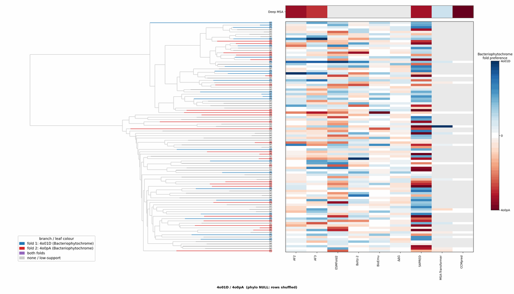

## Cluster metrics table

Per-cluster metrics underlying the figures above.

| cluster | n | neff | AF2_TM1 | AF2_TM2 | AF3_TM1 | AF3_TM2 | RE-MSAT-COM | RE-MSAT1 | RE-MSAT2 | ESM_SEQIDS | ESM_TM1 | ESM_TM2 | ΔΔG_Bias | ΔΔG_Bias_std | ΔΔG_frac_F1 | Boltz2_pref | S4PRED_pref | CCMpred_pref | BioEmu_pref |
| --- | --- | --- | --- | --- | --- | --- | --- | --- | --- | --- | --- | --- | --- | --- | --- | --- | --- | --- | --- |
| Deep | - | - | 0.62 | 0.73 | 0.82 | 0.93 | 0.42 | 0.44 | 0.42 | - | - | - | - | - | - | - | -0.03 | -0.0 | - |
| 000 | 1814.0 | 1090.0 | 0.67 | 0.57 | 0.66 | 0.53 | 0.04 | 0.04 | 0.04 | 001; 001; 003; 003; 009; 009; 002; 002; 007; 004 | 0.81 ± 0.04 | 0.86 ± 0.02 | -34.1 | 10.19 | 0.0 | 0.03 | 0.02 | 0.0 | 0.02 |
| 001 | 1336.0 | 750.0 | 0.31 | 0.33 | 0.74 | 0.84 | 0.02 | 0.02 | 0.03 | 002; 002; 004; 004; 003; 003; 009; 008; 008; 009 | 0.77 ± 0.03 | 0.82 ± 0.02 | -34.47 | 10.8 | 0.0 | 0.0 | 0.02 | 0.0 | 0.0 |
| 002 | 755.0 | 535.0 | 0.36 | 0.35 | 0.76 | 0.78 | 0.05 | 0.05 | 0.04 | 001; 001; 002; 002; 008; 008; 005; 005; 007; 007 | 0.79 ± 0.04 | 0.83 ± 0.04 | -31.03 | 11.56 | 0.0 | -0.0 | 0.02 | 0.0 | 0.0 |
| 003 | 360.0 | 144.0 | 0.34 | 0.34 | 0.46 | 0.46 | 0.02 | 0.02 | 0.02 | 008; 009; 008; 002; 002; 009; 001; 001; 003; 003 | 0.74 ± 0.06 | 0.76 ± 0.11 | -30.74 | 12.48 | 0.0 | 0.0 | -0.02 | 0.0 | 0.0 |
| 004 | 350.0 | 206.0 | 0.84 | 0.87 | 0.92 | 0.85 | 0.01 | 0.01 | 0.01 | 002; 003; 003; 002; 001; 001; 004; 004; 008; 008 | 0.83 ± 0.01 | 0.84 ± 0.03 | -28.47 | 9.17 | 0.0 | -0.0 | 0.01 | 0.0 | 0.04 |
| 005 | 300.0 | 185.0 | 0.7 | 0.76 | 0.72 | 0.84 | 0.03 | 0.03 | 0.04 | 001; 001; 002; 002; 008; 008; 003; 003; 006; 006 | 0.84 ± 0.06 | 0.84 ± 0.01 | -31.54 | 13.62 | 0.0 | -0.0 | -0.0 | 0.0 | -0.07 |
| 006 | 284.0 | 151.0 | 0.22 | 0.22 | 0.69 | 0.61 | 0.02 | 0.01 | 0.02 | 002; 002; 005; 005; 003; 003; 009; 009; 008; 008 | 0.80 ± 0.01 | 0.83 ± 0.02 | -28.73 | 12.68 | 0.0 | -0.01 | -0.01 | 0.0 | -0.0 |
| 007 | 282.0 | 174.0 | 0.75 | 0.66 | 0.8 | 0.86 | 0.01 | 0.01 | 0.01 | 001; 001; 003; 007; 006; 007; 006; 003; 002; 004 | 0.79 ± 0.01 | 0.84 ± 0.03 | -34.36 | 12.96 | 0.0 | 0.01 | -0.02 | 0.0 | 0.05 |
| 008 | 265.0 | 150.0 | 0.29 | 0.28 | 0.27 | 0.27 | 0.04 | 0.04 | 0.04 | 002; 002; 001; 001; 009; 009; 003; 003; 007; 010 | 0.81 ± 0.03 | 0.84 ± 0.03 | -26.35 | 12.01 | 0.0 | -0.0 | 0.0 | 0.0 | 0.0 |
| 009 | 248.0 | 157.0 | 0.25 | 0.26 | 0.45 | 0.44 | 0.0 | 0.0 | 0.0 | 002; 002; 008; 008; 007; 006; 007; 006; 001; 009 | 0.81 ± 0.01 | 0.85 ± 0.02 | -25.42 | 9.47 | 0.0 | 0.0 | -0.0 | 0.0 | 0.0 |
| 010 | 167.0 | 96.0 | 0.25 | 0.27 | 0.85 | 0.8 | 0.0 | 0.0 | 0.0 | 001; 003; 001; 003; 002; 002; 004; 004; 005; 005 | 0.82 ± 0.01 | 0.86 ± 0.01 | -34.01 | 11.52 | 0.0 | -0.0 | -0.03 | 0.0 | 0.01 |
| 011 | 166.0 | 71.0 | 0.31 | 0.29 | 0.36 | 0.36 | 0.04 | 0.04 | 0.03 | 007; 007; 004; 004; 001; 001; 002; 002; 006; 006 | 0.67 ± 0.07 | 0.69 ± 0.07 | -31.0 | 11.25 | 0.0 | 0.0 | -0.01 | 0.0 | 0.01 |
| 012 | 156.0 | 90.0 | 0.29 | 0.31 | 0.67 | 0.58 | 0.0 | 0.0 | 0.0 | 001; 001; 002; 002; 006; 006; 005; 005; 003; 003 | 0.83 ± 0.04 | 0.84 ± 0.05 | -29.05 | 8.13 | 0.0 | -0.03 | 0.01 | 0.0 | 0.0 |
| 013 | 154.0 | 77.0 | 0.23 | 0.23 | 0.45 | 0.46 | 0.05 | 0.05 | 0.05 | 001; 001; 009; 009; 007; 007; 003; 003; 004; 004 | 0.78 ± 0.05 | 0.78 ± 0.08 | -33.65 | 11.45 | 0.0 | 0.02 | -0.03 | 0.0 | 0.0 |
| 014 | 144.0 | 88.0 | 0.32 | 0.32 | 0.62 | 0.63 | 0.02 | 0.02 | 0.03 | 002; 002; 001; 001; 005; 005; 006; 006; 003; 003 | 0.78 ± 0.09 | 0.80 ± 0.08 | -26.34 | 12.57 | 0.0 | -0.0 | -0.03 | 0.0 | 0.0 |
| 015 | 140.0 | 80.0 | 0.19 | 0.17 | 0.33 | 0.32 | 0.01 | 0.01 | 0.01 | 003; 003; 001; 001; 005; 004; 004; 005; 002; 002 | 0.80 ± 0.03 | 0.84 ± 0.03 | -25.09 | 11.37 | 0.0 | -0.01 | 0.0 | 0.0 | -0.0 |
| 016 | 135.0 | 69.0 | 0.32 | 0.36 | 0.61 | 0.62 | 0.0 | 0.0 | 0.0 | - | - | - | -26.74 | 12.56 | 0.0 | -0.01 | -0.02 | - | 0.0 |
| 017 | 131.0 | 58.0 | 0.26 | 0.26 | 0.36 | 0.38 | 0.01 | 0.01 | 0.01 | - | - | - | -33.48 | 14.53 | 0.0 | 0.01 | -0.02 | - | 0.0 |
| 018 | 123.0 | 75.0 | 0.31 | 0.32 | 0.83 | 0.78 | 0.02 | 0.02 | 0.01 | - | - | - | -30.93 | 14.31 | 0.0 | -0.02 | -0.01 | - | -0.0 |
| 019 | 120.0 | 68.0 | 0.22 | 0.28 | 0.48 | 0.42 | 0.01 | 0.01 | 0.01 | - | - | - | -29.78 | 14.01 | 0.0 | 0.01 | 0.01 | - | 0.01 |
| 020 | 119.0 | 81.0 | 0.35 | 0.32 | 0.41 | 0.37 | 0.01 | 0.01 | 0.01 | - | - | - | -30.27 | 12.73 | 0.0 | 0.02 | 0.02 | - | 0.03 |
| 021 | 115.0 | 74.0 | 0.61 | 0.63 | 0.71 | 0.71 | 0.01 | 0.01 | 0.01 | - | - | - | -23.24 | 11.44 | 0.0 | 0.0 | 0.02 | - | 0.0 |
| 022 | 112.0 | 58.0 | 0.24 | 0.22 | 0.37 | 0.38 | 0.0 | 0.0 | 0.0 | - | - | - | -30.23 | 15.75 | 0.0 | 0.0 | 0.02 | - | -0.0 |
| 023 | 109.0 | 50.0 | 0.32 | 0.34 | 0.69 | 0.58 | 0.02 | 0.02 | 0.02 | - | - | - | -24.79 | 9.34 | 0.0 | -0.0 | -0.02 | - | 0.0 |
| 024 | 108.0 | 59.0 | 0.38 | 0.36 | 0.37 | 0.39 | 0.0 | 0.0 | 0.0 | - | - | - | -27.78 | 13.18 | 0.0 | 0.02 | 0.0 | - | 0.01 |
| 025 | 105.0 | 51.0 | 0.3 | 0.3 | 0.43 | 0.43 | 0.02 | 0.02 | 0.03 | - | - | - | -28.4 | 11.58 | 0.0 | 0.02 | -0.03 | - | -0.0 |
| 026 | 105.0 | 56.0 | 0.22 | 0.24 | 0.32 | 0.31 | 0.01 | 0.01 | 0.01 | - | - | - | -24.71 | 12.47 | 0.0 | 0.02 | -0.02 | - | -0.0 |
| 027 | 102.0 | 50.0 | 0.5 | 0.49 | 0.44 | 0.43 | 0.0 | 0.0 | 0.01 | - | - | - | -26.1 | 10.35 | 0.0 | -0.01 | -0.03 | - | 0.02 |
| 028 | 100.0 | 61.0 | 0.38 | 0.37 | 0.6 | 0.56 | 0.01 | 0.01 | 0.01 | - | - | - | -26.92 | 12.83 | 0.0 | 0.0 | -0.0 | - | 0.01 |

[output cut: 71 more lines]